# Side-by-side Bayes factor and equivalence test in R: A tutorial

Peder M Isager

May 10, 2018

## Introduction

This short tutorial will guide you through the steps reqiured to perform a side-by-side Bayes factor and equivalence test in the free software environment R. The functions used for this procedure are based on the standard TOST functions of the TOSTER package in R, with some added functionality to incorporate a Bayes factor analsysis. The example in this tutorial illustrates the procedure for an independent sample *t*-test.

## Step by step tutorial

#### Step 1: Install R

R is available for Linux, MacOS, and Windows, and can be downloaded from [The Comprehensive R Archive Network (CRAN)](https://cran.r-project.org/). If you are unfamiliar with R, a short introduction can be found [here](https://www.statmethods.net/r-tutorial/index.html).

#### Step 2: Install RStudio (optional)

RStudio is a free integrated development environment (IDE) for R. It can be installed from [www.rstudio.com](https://www.rstudio.com/products/rstudio/download/) Rstudio serves to make the experience of working with R more user-friendly, especially for new users. Its layout is similar to that of the Matlab IDE, or the Spyder IDE for the Python language.

#### Step 3: Source and or download the R script

After installation, open R or Rstudio. In the console window, run the following command to retrieve the required function from Github:

```r
source("https://raw.githubusercontent.com/Lakens/BF_TOST/master/TOSTtwo.bf.R")
```

If you want to download the file containting the function instead (e.g. for offline access, or if you want to edit its content) you can run the following lines of code instead:

```r
download.file(url = "https://raw.githubusercontent.com/Lakens/BF_TOST/master/TOSTtwo.bf.R", destfile = paste0(getwd(), "/TOSTtwo.bf.R"))

source(paste0(getwd(), "/TOSTtwo.bf.R"))
```

#### Step 4: Obtain required statistics from your data

You can conduct a two-one-sided-test of equivalence (TOST), as well as calculate Bayes factors, using only summary statistics of data. Let us take an independent samples t-test as an example. For this we need the group means, standard deviations, and sample sizes from the data. Run the following lines of code in you R console to define these parameters (using some arbitrary values) in R:

```r
group1_mean <- 0
group2_mean <- 0.2

group1_stdev <- 0.5
group2_stdev <- 0.4

group1_n <- 32
group2_n <- 34
```

In addtion, we need to define the equivalence bounds (stated in values of Cohen’s d), and the parameters for the Bayesian prior. Run the following lines of code in you R console to define these parameters in R:

```r
lower_bound <- -1
upper_bound <-  1
prior_bf <- 0.1
prior_degfree <- 64
```

#### Step 5: Run a two-one-sided-test in R

The `TOSTtwo.bf()` function allows us to conduct an equivalence test for an independent samples t test, specifying equivalence bounds in values of Cohen’s d. To conduct the equivalence test, and calculate a Bayes Factor with a normally distributed prior, run the following command in you R console:

```r
TOSTtwo.bf(m1 = group1_mean, m2 = group2_mean, sd1 = group1_stdev, sd2 = group2_stdev, n1 = group1_n, n2 = group2_n, low_eqbound_d = lower_bound, high_eqbound_d = upper_bound, alpha = 0.05, prior_dist = "normal", effect_prior = prior_bf, df_prior = prior_degfree)
```

Notice that the values we assigned in step 4 are now being used as input to the `TOSTtwo.bf()` function arguments. This is done here merely to make it clear which argument requires which input. You can also insert numbers directly into the function input if you prefer.

Running this command will provide you with the following output, summarizing the results of the test:

```
## Using alpha = 0.05 Welch's t-test was non-significant, t(59.36101) = -1.78754, p = 0.07895512
```

```
##
## Using alpha = 0.05 the equivalence test based on Welch's t-test  was significant, t(59.36101) = 2.259176, p = 0.01377909
```

```
## TOST results:
##   t-value 1  p-value 1 t-value 2    p-value 2       df
## 1  2.259176 0.01377909 -5.834257 1.195383e-07 59.36101
##
## Equivalence bounds (raw scores):
##   low bound raw high bound raw
## 1    -0.4527693      0.4527693
##
## TOST confidence interval:
##   Lower Limit 90% CI raw Upper Limit 90% CI raw
## 1             -0.3869531            -0.01304693
##
## Bayes Results:
##   Bayes Factor Likelihood (alternative) Likelihood (null)
## 1     0.243217               0.01985499        0.08163485
##
## Bayes Summary:
##   Prior Distribution Effect Size Prior SE Prior df Prior
## 1             normal               0.1     0.05       64
```

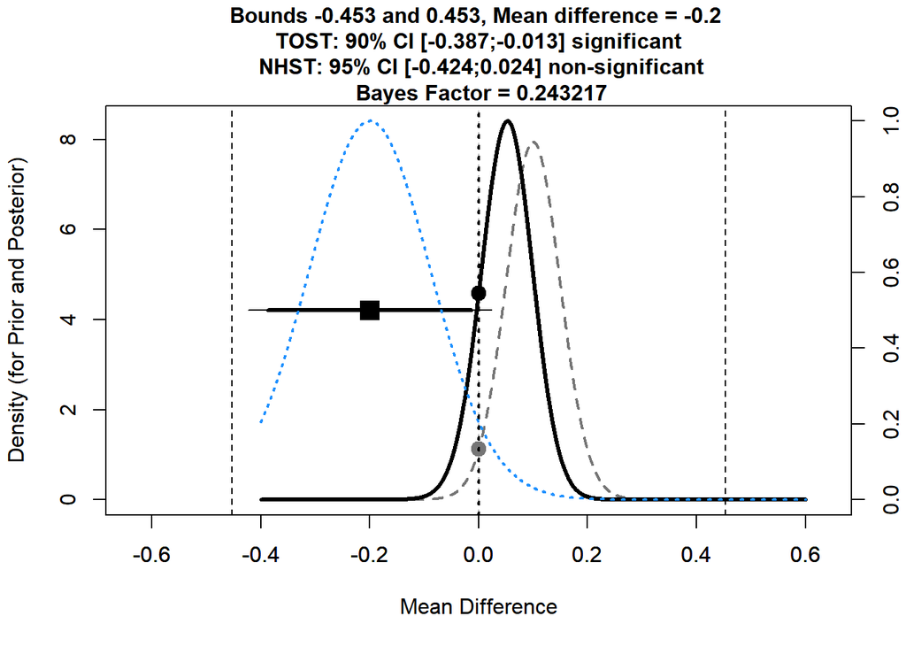

Notice that in the plot, the position of the dashed lines representing the upper and lower equivalence bounds are not consistent with the equivalence bound values we defined in step 4. This is because the `TOSTtwo()` function recalculates the bound values from Cohen’s d back into the raw scale (based on the standard deviations provided in the function input) before plotting.